# Evaluating LLM-Generated Synthetic Datasets for SMS Smishing Detection

This notebook walks through the full ML pipeline for comparing SMS smishing classifiers trained on:

- **Manual-only**: manually curated real-world SMS data
- **Synthetic-only**: LLM-generated synthetic SMS data (size-matched to manual)
- **Combined**: both datasets together

All experiments are evaluated against a manual (real-world) holdout set across 30 random seeds and 3 classifier types.

## 1. Setup

```python
import sys
from pathlib import Path

# Ensure src/ is importable when running from notebooks/
project_root = Path.cwd().parent if Path.cwd().name == "notebooks" else Path.cwd()
sys.path.insert(0, str(project_root))

import pandas as pd
import matplotlib.pyplot as plt
from IPython.display import display, Markdown
```

## 2. Dataset Loading & Preprocessing

```python
from src.data.preprocessing import run_preprocessing

manual, synthetic, combined = run_preprocessing(mode="drop_exact_duplicates", save=True)

print(f"Manual:    {len(manual):,} rows")
print(f"Synthetic: {len(synthetic):,} rows")
print(f"Combined:  {len(combined):,} rows")
```

```
Manual:    5,949 rows
Synthetic: 7,991 rows
Combined:  13,940 rows
```

## 3. Dataset Audit & Provenance Analysis

The synthetic dataset was generated using the manual dataset as source material. We audit for duplicates, overlap, and potential leakage.

```python
from src.data.audit import run_audit

audit_results = run_audit(manual, synthetic, save=True)

display(Markdown("### Dataset Summary"))
display(audit_results["audit"])
```

Dataset Summary

|  | dataset | row_count | ham_count | spam_count | smishing_count | exact_duplicate_count | duplicate_pct | avg_message_length | vocabulary_size |
| --- | --- | --- | --- | --- | --- | --- | --- | --- | --- |
| 0 | manual | 5949 | 4834 | 487 | 628 | 0 | 0.0 | 83.0 | 14883 |
| 1 | synthetic | 7991 | 3393 | 1944 | 2654 | 0 | 0.0 | 112.6 | 12228 |

```python
display(Markdown("### Leakage Audit"))
display(audit_results["leakage"])
```

Leakage Audit

|  | metric | value |
| --- | --- | --- |
| 0 | manual_unique_texts | 5949.00 |
| 1 | synthetic_unique_texts | 7991.00 |
| 2 | overlapping_texts | 4169.00 |
| 3 | overlap_pct_of_manual | 70.08 |
| 4 | overlap_pct_of_synthetic | 52.17 |

```python
display(Markdown("### Top Duplicate Messages (across both datasets)"))
display(audit_results["top_duplicates"].head(10))
```

Top Duplicate Messages (across both datasets)

|  | text | count | datasets | label |
| --- | --- | --- | --- | --- |
| 0 | Todays Vodafone numbers ending 7548 are select... | 2 | manual,synthetic | smishing |
| 1 | Oh, the grand is having a bit of a party but i... | 2 | manual,synthetic | ham |
| 2 | Oh... Lk tt den we take e one tt ends at cine ... | 2 | manual,synthetic | ham |
| 3 | Oh... Kay... On sat right? | 2 | manual,synthetic | ham |
| 4 | Oh... Icic... K lor, den meet other day... | 2 | manual,synthetic | ham |
| 5 | Oh... I was thkin of goin yogasana at 10 den n... | 2 | manual,synthetic | ham |
| 6 | Oh... Haha... Den we shld had went today too..... | 2 | manual,synthetic | ham |
| 7 | Oh. U must have taken your REAL Valentine out ... | 2 | manual,synthetic | ham |
| 8 | Oh, then your phone phoned me but it disconnected | 2 | manual,synthetic | ham |
| 9 | Oh, my love, it's soooo good to hear from you.... | 2 | manual,synthetic | ham |

## 4. Duplicate Analysis

```python
for name, df in [("Manual", manual), ("Synthetic", synthetic)]:
    n_total = len(df)
    n_unique = df["text"].nunique()
    print(f"{name}: {n_total:,} rows, {n_unique:,} unique texts, {n_total - n_unique:,} duplicates removed")
```

```
Manual: 5,949 rows, 5,949 unique texts, 0 duplicates removed
Synthetic: 7,991 rows, 7,991 unique texts, 0 duplicates removed
```

## 5. Cross-Dataset Overlap

```python
overlap = audit_results["overlap"]
print(f"Exact text matches between datasets: {len(overlap):,}")
print(f"Overlap as % of manual: {len(overlap) / manual['text'].nunique() * 100:.1f}%")
print(f"Overlap as % of synthetic: {len(overlap) / synthetic['text'].nunique() * 100:.1f}%")
```

```
Exact text matches between datasets: 4,169
Overlap as % of manual: 70.1%
Overlap as % of synthetic: 52.2%
```

## 6. Class Distribution

```python
fig, axes = plt.subplots(1, 2, figsize=(10, 4), sharey=True)
for ax, (name, df) in zip(axes, [("Manual", manual), ("Synthetic", synthetic)]):
    counts = df["label"].value_counts().reindex(["ham", "spam", "smishing"])
    counts.plot.bar(ax=ax, color=["steelblue", "orange", "firebrick"])
    ax.set_title(f"{name} Dataset")
    ax.set_ylabel("Count")
    ax.tick_params(axis="x", rotation=0)
plt.tight_layout()
plt.show()
```

[output not shown]

## 7. Feature Engineering

Each model uses a scikit-learn pipeline that combines:

- **TF-IDF** vectorization on `text_clean` (unigrams + bigrams, sublinear TF)
- **Indicator features**: `has_url`, `has_email`, `has_phone`

```python
from src.features.text_features import build_feature_transformer

ft = build_feature_transformer()
print("Feature transformer:")
print(ft)
```

```
Feature transformer:
ColumnTransformer(transformers=[('tfidf',
                                 TfidfVectorizer(max_df=0.95, min_df=2,
                                                 ngram_range=(1, 2),
                                                 sublinear_tf=True),
                                 'text_clean'),
                                ('indicators', 'passthrough',
                                 ['has_url', 'has_email', 'has_phone'])])
```

## 8. Model Training

We train 3 classifiers across 3 training strategies and 30 random seeds (270 total runs).

**Models**: MultinomialNB, Logistic Regression, LinearSVC (calibrated)

**Training strategies** (all tested against Manual Holdout):

```python
from src.models.train import run_experiments

metrics_df = run_experiments(manual, synthetic, verbose=True)
```

```
  [1/270] seed=1 model=MultinomialNB exp=manual_only
```

```
  [2/270] seed=1 model=MultinomialNB exp=synthetic_only
```

```
  [3/270] seed=1 model=MultinomialNB exp=combined
```

```
  [4/270] seed=1 model=LogisticRegression exp=manual_only
```

```
  [5/270] seed=1 model=LogisticRegression exp=synthetic_only
```

```
  [6/270] seed=1 model=LogisticRegression exp=combined
```

```
  [7/270] seed=1 model=LinearSVC exp=manual_only
```

```
  [8/270] seed=1 model=LinearSVC exp=synthetic_only
```

```
  [9/270] seed=1 model=LinearSVC exp=combined
```

```
  [10/270] seed=2 model=MultinomialNB exp=manual_only
  [11/270] seed=2 model=MultinomialNB exp=synthetic_only
```

```
  [12/270] seed=2 model=MultinomialNB exp=combined
```

```
  [13/270] seed=2 model=LogisticRegression exp=manual_only
```

```
  [14/270] seed=2 model=LogisticRegression exp=synthetic_only
```

```
  [15/270] seed=2 model=LogisticRegression exp=combined
```

```
  [16/270] seed=2 model=LinearSVC exp=manual_only
```

```
  [17/270] seed=2 model=LinearSVC exp=synthetic_only
```

```
  [18/270] seed=2 model=LinearSVC exp=combined
```

```
  [19/270] seed=3 model=MultinomialNB exp=manual_only
  [20/270] seed=3 model=MultinomialNB exp=synthetic_only
```

```
  [21/270] seed=3 model=MultinomialNB exp=combined
```

```
  [22/270] seed=3 model=LogisticRegression exp=manual_only
```

```
  [23/270] seed=3 model=LogisticRegression exp=synthetic_only
```

```
  [24/270] seed=3 model=LogisticRegression exp=combined
```

```
  [25/270] seed=3 model=LinearSVC exp=manual_only
```

```
  [26/270] seed=3 model=LinearSVC exp=synthetic_only
```

```
  [27/270] seed=3 model=LinearSVC exp=combined
```

```
  [28/270] seed=4 model=MultinomialNB exp=manual_only
  [29/270] seed=4 model=MultinomialNB exp=synthetic_only
```

```
  [30/270] seed=4 model=MultinomialNB exp=combined
```

```
  [31/270] seed=4 model=LogisticRegression exp=manual_only
```

```
  [32/270] seed=4 model=LogisticRegression exp=synthetic_only
```

```
  [33/270] seed=4 model=LogisticRegression exp=combined
```

```
  [34/270] seed=4 model=LinearSVC exp=manual_only
```

```
  [35/270] seed=4 model=LinearSVC exp=synthetic_only
```

```
  [36/270] seed=4 model=LinearSVC exp=combined
```

```
  [37/270] seed=5 model=MultinomialNB exp=manual_only
  [38/270] seed=5 model=MultinomialNB exp=synthetic_only
```

```
  [39/270] seed=5 model=MultinomialNB exp=combined
```

```
  [40/270] seed=5 model=LogisticRegression exp=manual_only
```

```
  [41/270] seed=5 model=LogisticRegression exp=synthetic_only
```

```
  [42/270] seed=5 model=LogisticRegression exp=combined
```

```
  [43/270] seed=5 model=LinearSVC exp=manual_only
```

```
  [44/270] seed=5 model=LinearSVC exp=synthetic_only
```

```
  [45/270] seed=5 model=LinearSVC exp=combined
```

```
  [46/270] seed=6 model=MultinomialNB exp=manual_only
  [47/270] seed=6 model=MultinomialNB exp=synthetic_only
```

```
  [48/270] seed=6 model=MultinomialNB exp=combined
```

```
  [49/270] seed=6 model=LogisticRegression exp=manual_only
```

```
  [50/270] seed=6 model=LogisticRegression exp=synthetic_only
```

```
  [51/270] seed=6 model=LogisticRegression exp=combined
```

```
  [52/270] seed=6 model=LinearSVC exp=manual_only
```

```
  [53/270] seed=6 model=LinearSVC exp=synthetic_only
```

```
  [54/270] seed=6 model=LinearSVC exp=combined
```

```
  [55/270] seed=7 model=MultinomialNB exp=manual_only
  [56/270] seed=7 model=MultinomialNB exp=synthetic_only
```

```
  [57/270] seed=7 model=MultinomialNB exp=combined
```

```
  [58/270] seed=7 model=LogisticRegression exp=manual_only
```

```
  [59/270] seed=7 model=LogisticRegression exp=synthetic_only
```

```
  [60/270] seed=7 model=LogisticRegression exp=combined
```

```
  [61/270] seed=7 model=LinearSVC exp=manual_only
```

```
  [62/270] seed=7 model=LinearSVC exp=synthetic_only
```

```
  [63/270] seed=7 model=LinearSVC exp=combined
```

```
  [64/270] seed=8 model=MultinomialNB exp=manual_only
  [65/270] seed=8 model=MultinomialNB exp=synthetic_only
```

```
  [66/270] seed=8 model=MultinomialNB exp=combined
```

```
  [67/270] seed=8 model=LogisticRegression exp=manual_only
```

```
  [68/270] seed=8 model=LogisticRegression exp=synthetic_only
```

```
  [69/270] seed=8 model=LogisticRegression exp=combined
```

```
  [70/270] seed=8 model=LinearSVC exp=manual_only
```

```
  [71/270] seed=8 model=LinearSVC exp=synthetic_only
```

```
  [72/270] seed=8 model=LinearSVC exp=combined
```

```
  [73/270] seed=9 model=MultinomialNB exp=manual_only
  [74/270] seed=9 model=MultinomialNB exp=synthetic_only
```

```
  [75/270] seed=9 model=MultinomialNB exp=combined
```

```
  [76/270] seed=9 model=LogisticRegression exp=manual_only
```

```
  [77/270] seed=9 model=LogisticRegression exp=synthetic_only
```

```
  [78/270] seed=9 model=LogisticRegression exp=combined
```

```
  [79/270] seed=9 model=LinearSVC exp=manual_only
```

```
  [80/270] seed=9 model=LinearSVC exp=synthetic_only
```

```
  [81/270] seed=9 model=LinearSVC exp=combined
```

```
  [82/270] seed=10 model=MultinomialNB exp=manual_only
  [83/270] seed=10 model=MultinomialNB exp=synthetic_only
```

```
  [84/270] seed=10 model=MultinomialNB exp=combined
```

```
  [85/270] seed=10 model=LogisticRegression exp=manual_only
```

```
  [86/270] seed=10 model=LogisticRegression exp=synthetic_only
```

```
  [87/270] seed=10 model=LogisticRegression exp=combined
```

```
  [88/270] seed=10 model=LinearSVC exp=manual_only
```

```
  [89/270] seed=10 model=LinearSVC exp=synthetic_only
```

```
  [90/270] seed=10 model=LinearSVC exp=combined
```

```
  [91/270] seed=11 model=MultinomialNB exp=manual_only
  [92/270] seed=11 model=MultinomialNB exp=synthetic_only
```

```
  [93/270] seed=11 model=MultinomialNB exp=combined
```

```
  [94/270] seed=11 model=LogisticRegression exp=manual_only
```

```
  [95/270] seed=11 model=LogisticRegression exp=synthetic_only
```

```
  [96/270] seed=11 model=LogisticRegression exp=combined
```

```
  [97/270] seed=11 model=LinearSVC exp=manual_only
```

```
  [98/270] seed=11 model=LinearSVC exp=synthetic_only
```

```
  [99/270] seed=11 model=LinearSVC exp=combined
```

```
  [100/270] seed=12 model=MultinomialNB exp=manual_only
  [101/270] seed=12 model=MultinomialNB exp=synthetic_only
```

```
  [102/270] seed=12 model=MultinomialNB exp=combined
```

```
  [103/270] seed=12 model=LogisticRegression exp=manual_only
```

```
  [104/270] seed=12 model=LogisticRegression exp=synthetic_only
```

```
  [105/270] seed=12 model=LogisticRegression exp=combined
```

```
  [106/270] seed=12 model=LinearSVC exp=manual_only
```

```
  [107/270] seed=12 model=LinearSVC exp=synthetic_only
```

```
  [108/270] seed=12 model=LinearSVC exp=combined
```

```
  [109/270] seed=13 model=MultinomialNB exp=manual_only
  [110/270] seed=13 model=MultinomialNB exp=synthetic_only
```

```
  [111/270] seed=13 model=MultinomialNB exp=combined
```

```
  [112/270] seed=13 model=LogisticRegression exp=manual_only
```

```
  [113/270] seed=13 model=LogisticRegression exp=synthetic_only
```

```
  [114/270] seed=13 model=LogisticRegression exp=combined
```

```
  [115/270] seed=13 model=LinearSVC exp=manual_only
```

```
  [116/270] seed=13 model=LinearSVC exp=synthetic_only
```

```
  [117/270] seed=13 model=LinearSVC exp=combined
```

```
  [118/270] seed=14 model=MultinomialNB exp=manual_only
  [119/270] seed=14 model=MultinomialNB exp=synthetic_only
```

```
  [120/270] seed=14 model=MultinomialNB exp=combined
```

```
  [121/270] seed=14 model=LogisticRegression exp=manual_only
```

```
  [122/270] seed=14 model=LogisticRegression exp=synthetic_only
```

```
  [123/270] seed=14 model=LogisticRegression exp=combined
```

```
  [124/270] seed=14 model=LinearSVC exp=manual_only
```

```
  [125/270] seed=14 model=LinearSVC exp=synthetic_only
```

```
  [126/270] seed=14 model=LinearSVC exp=combined
```

```
  [127/270] seed=15 model=MultinomialNB exp=manual_only
  [128/270] seed=15 model=MultinomialNB exp=synthetic_only
```

```
  [129/270] seed=15 model=MultinomialNB exp=combined
```

```
  [130/270] seed=15 model=LogisticRegression exp=manual_only
```

```
  [131/270] seed=15 model=LogisticRegression exp=synthetic_only
```

```
  [132/270] seed=15 model=LogisticRegression exp=combined
```

```
  [133/270] seed=15 model=LinearSVC exp=manual_only
```

```
  [134/270] seed=15 model=LinearSVC exp=synthetic_only
```

```
  [135/270] seed=15 model=LinearSVC exp=combined
```

```
  [136/270] seed=16 model=MultinomialNB exp=manual_only
  [137/270] seed=16 model=MultinomialNB exp=synthetic_only
```

```
  [138/270] seed=16 model=MultinomialNB exp=combined
```

```
  [139/270] seed=16 model=LogisticRegression exp=manual_only
```

```
  [140/270] seed=16 model=LogisticRegression exp=synthetic_only
```

```
  [141/270] seed=16 model=LogisticRegression exp=combined
```

```
  [142/270] seed=16 model=LinearSVC exp=manual_only
```

```
  [143/270] seed=16 model=LinearSVC exp=synthetic_only
```

```
  [144/270] seed=16 model=LinearSVC exp=combined
```

```
  [145/270] seed=17 model=MultinomialNB exp=manual_only
  [146/270] seed=17 model=MultinomialNB exp=synthetic_only
```

```
  [147/270] seed=17 model=MultinomialNB exp=combined
```

```
  [148/270] seed=17 model=LogisticRegression exp=manual_only
```

```
  [149/270] seed=17 model=LogisticRegression exp=synthetic_only
```

```
  [150/270] seed=17 model=LogisticRegression exp=combined
```

```
  [151/270] seed=17 model=LinearSVC exp=manual_only
```

```
  [152/270] seed=17 model=LinearSVC exp=synthetic_only
```

```
  [153/270] seed=17 model=LinearSVC exp=combined
```

```
  [154/270] seed=18 model=MultinomialNB exp=manual_only
  [155/270] seed=18 model=MultinomialNB exp=synthetic_only
```

```
  [156/270] seed=18 model=MultinomialNB exp=combined
```

```
  [157/270] seed=18 model=LogisticRegression exp=manual_only
```

```
  [158/270] seed=18 model=LogisticRegression exp=synthetic_only
```

```
  [159/270] seed=18 model=LogisticRegression exp=combined
```

```
  [160/270] seed=18 model=LinearSVC exp=manual_only
```

```
  [161/270] seed=18 model=LinearSVC exp=synthetic_only
```

```
  [162/270] seed=18 model=LinearSVC exp=combined
```

```
  [163/270] seed=19 model=MultinomialNB exp=manual_only
  [164/270] seed=19 model=MultinomialNB exp=synthetic_only
```

```
  [165/270] seed=19 model=MultinomialNB exp=combined
```

```
  [166/270] seed=19 model=LogisticRegression exp=manual_only
```

```
  [167/270] seed=19 model=LogisticRegression exp=synthetic_only
```

```
  [168/270] seed=19 model=LogisticRegression exp=combined
```

```
  [169/270] seed=19 model=LinearSVC exp=manual_only
```

```
  [170/270] seed=19 model=LinearSVC exp=synthetic_only
```

```
  [171/270] seed=19 model=LinearSVC exp=combined
```

```
  [172/270] seed=20 model=MultinomialNB exp=manual_only
  [173/270] seed=20 model=MultinomialNB exp=synthetic_only
```

```
  [174/270] seed=20 model=MultinomialNB exp=combined
```

```
  [175/270] seed=20 model=LogisticRegression exp=manual_only
```

```
  [176/270] seed=20 model=LogisticRegression exp=synthetic_only
```

```
  [177/270] seed=20 model=LogisticRegression exp=combined
```

```
  [178/270] seed=20 model=LinearSVC exp=manual_only
```

```
  [179/270] seed=20 model=LinearSVC exp=synthetic_only
```

```
  [180/270] seed=20 model=LinearSVC exp=combined
```

```
  [181/270] seed=21 model=MultinomialNB exp=manual_only
```

```
  [182/270] seed=21 model=MultinomialNB exp=synthetic_only
```

```
  [183/270] seed=21 model=MultinomialNB exp=combined
```

```
  [184/270] seed=21 model=LogisticRegression exp=manual_only
```

```
  [185/270] seed=21 model=LogisticRegression exp=synthetic_only
```

```
  [186/270] seed=21 model=LogisticRegression exp=combined
```

```
  [187/270] seed=21 model=LinearSVC exp=manual_only
```

```
  [188/270] seed=21 model=LinearSVC exp=synthetic_only
```

```
  [189/270] seed=21 model=LinearSVC exp=combined
```

```
  [190/270] seed=22 model=MultinomialNB exp=manual_only
  [191/270] seed=22 model=MultinomialNB exp=synthetic_only
```

```
  [192/270] seed=22 model=MultinomialNB exp=combined
```

```
  [193/270] seed=22 model=LogisticRegression exp=manual_only
```

```
  [194/270] seed=22 model=LogisticRegression exp=synthetic_only
```

```
  [195/270] seed=22 model=LogisticRegression exp=combined
```

```
  [196/270] seed=22 model=LinearSVC exp=manual_only
```

```
  [197/270] seed=22 model=LinearSVC exp=synthetic_only
```

```
  [198/270] seed=22 model=LinearSVC exp=combined
```

```
  [199/270] seed=23 model=MultinomialNB exp=manual_only
```

```
  [200/270] seed=23 model=MultinomialNB exp=synthetic_only
```

```
  [201/270] seed=23 model=MultinomialNB exp=combined
```

```
  [202/270] seed=23 model=LogisticRegression exp=manual_only
```

```
  [203/270] seed=23 model=LogisticRegression exp=synthetic_only
```

```
  [204/270] seed=23 model=LogisticRegression exp=combined
```

```
  [205/270] seed=23 model=LinearSVC exp=manual_only
```

```
  [206/270] seed=23 model=LinearSVC exp=synthetic_only
```

```
  [207/270] seed=23 model=LinearSVC exp=combined
```

```
  [208/270] seed=24 model=MultinomialNB exp=manual_only
```

```
  [209/270] seed=24 model=MultinomialNB exp=synthetic_only
```

```
  [210/270] seed=24 model=MultinomialNB exp=combined
```

```
  [211/270] seed=24 model=LogisticRegression exp=manual_only
```

```
  [212/270] seed=24 model=LogisticRegression exp=synthetic_only
```

```
  [213/270] seed=24 model=LogisticRegression exp=combined
```

```
  [214/270] seed=24 model=LinearSVC exp=manual_only
```

```
  [215/270] seed=24 model=LinearSVC exp=synthetic_only
```

```
  [216/270] seed=24 model=LinearSVC exp=combined
```

```
  [217/270] seed=25 model=MultinomialNB exp=manual_only
  [218/270] seed=25 model=MultinomialNB exp=synthetic_only
```

```
  [219/270] seed=25 model=MultinomialNB exp=combined
```

```
  [220/270] seed=25 model=LogisticRegression exp=manual_only
```

```
  [221/270] seed=25 model=LogisticRegression exp=synthetic_only
```

```
  [222/270] seed=25 model=LogisticRegression exp=combined
```

```
  [223/270] seed=25 model=LinearSVC exp=manual_only
```

```
  [224/270] seed=25 model=LinearSVC exp=synthetic_only
```

```
  [225/270] seed=25 model=LinearSVC exp=combined
```

```
  [226/270] seed=26 model=MultinomialNB exp=manual_only
  [227/270] seed=26 model=MultinomialNB exp=synthetic_only
```

```
  [228/270] seed=26 model=MultinomialNB exp=combined
```

```
  [229/270] seed=26 model=LogisticRegression exp=manual_only
```

```
  [230/270] seed=26 model=LogisticRegression exp=synthetic_only
```

```
  [231/270] seed=26 model=LogisticRegression exp=combined
```

```
  [232/270] seed=26 model=LinearSVC exp=manual_only
```

```
  [233/270] seed=26 model=LinearSVC exp=synthetic_only
```

```
  [234/270] seed=26 model=LinearSVC exp=combined
```

```
  [235/270] seed=27 model=MultinomialNB exp=manual_only
  [236/270] seed=27 model=MultinomialNB exp=synthetic_only
```

```
  [237/270] seed=27 model=MultinomialNB exp=combined
```

```
  [238/270] seed=27 model=LogisticRegression exp=manual_only
```

```
  [239/270] seed=27 model=LogisticRegression exp=synthetic_only
```

```
  [240/270] seed=27 model=LogisticRegression exp=combined
```

```
  [241/270] seed=27 model=LinearSVC exp=manual_only
```

```
  [242/270] seed=27 model=LinearSVC exp=synthetic_only
```

```
  [243/270] seed=27 model=LinearSVC exp=combined
```

```
  [244/270] seed=28 model=MultinomialNB exp=manual_only
  [245/270] seed=28 model=MultinomialNB exp=synthetic_only
```

```
  [246/270] seed=28 model=MultinomialNB exp=combined
```

```
  [247/270] seed=28 model=LogisticRegression exp=manual_only
```

```
  [248/270] seed=28 model=LogisticRegression exp=synthetic_only
```

```
  [249/270] seed=28 model=LogisticRegression exp=combined
```

```
  [250/270] seed=28 model=LinearSVC exp=manual_only
```

```
  [251/270] seed=28 model=LinearSVC exp=synthetic_only
```

```
  [252/270] seed=28 model=LinearSVC exp=combined
```

```
  [253/270] seed=29 model=MultinomialNB exp=manual_only
  [254/270] seed=29 model=MultinomialNB exp=synthetic_only
```

```
  [255/270] seed=29 model=MultinomialNB exp=combined
```

```
  [256/270] seed=29 model=LogisticRegression exp=manual_only
```

```
  [257/270] seed=29 model=LogisticRegression exp=synthetic_only
```

```
  [258/270] seed=29 model=LogisticRegression exp=combined
```

```
  [259/270] seed=29 model=LinearSVC exp=manual_only
```

```
  [260/270] seed=29 model=LinearSVC exp=synthetic_only
```

```
  [261/270] seed=29 model=LinearSVC exp=combined
```

```
  [262/270] seed=30 model=MultinomialNB exp=manual_only
  [263/270] seed=30 model=MultinomialNB exp=synthetic_only
```

```
  [264/270] seed=30 model=MultinomialNB exp=combined
```

```
  [265/270] seed=30 model=LogisticRegression exp=manual_only
```

```
  [266/270] seed=30 model=LogisticRegression exp=synthetic_only
```

```
  [267/270] seed=30 model=LogisticRegression exp=combined
```

```
  [268/270] seed=30 model=LinearSVC exp=manual_only
```

```
  [269/270] seed=30 model=LinearSVC exp=synthetic_only
```

```
  [270/270] seed=30 model=LinearSVC exp=combined
```

## 9. Model Evaluation

```python
display(Markdown("### Mean Smishing F1 by Model and Training Strategy"))
summary = (
    metrics_df.groupby(["model_name", "experiment_id"])["smishing_f1"]
    .agg(["mean", "std"])
    .round(4)
    .unstack()
)
display(summary)
```

Mean Smishing F1 by Model and Training Strategy

| experiment_id model_name | mean combined | mean manual_only | mean synthetic_only | std combined | std manual_only | std synthetic_only |
| --- | --- | --- | --- | --- | --- | --- |
| LinearSVC | 0.9393 | 0.8702 | 0.9296 | 0.0149 | 0.0228 | 0.0158 |
| LogisticRegression | 0.9245 | 0.8678 | 0.8995 | 0.0172 | 0.0226 | 0.0157 |
| MultinomialNB | 0.9062 | 0.8572 | 0.8872 | 0.0200 | 0.0190 | 0.0164 |

```python
display(Markdown("### Mean Macro F1 by Model and Training Strategy"))
summary_macro = (
    metrics_df.groupby(["model_name", "experiment_id"])["macro_f1"]
    .agg(["mean", "std"])
    .round(4)
    .unstack()
)
display(summary_macro)
```

Mean Macro F1 by Model and Training Strategy

| experiment_id model_name | mean combined | mean manual_only | mean synthetic_only | std combined | std manual_only | std synthetic_only |
| --- | --- | --- | --- | --- | --- | --- |
| LinearSVC | 0.9490 | 0.8716 | 0.9409 | 0.0123 | 0.0171 | 0.0121 |
| LogisticRegression | 0.9359 | 0.8716 | 0.9132 | 0.0134 | 0.0173 | 0.0128 |
| MultinomialNB | 0.9188 | 0.8328 | 0.9039 | 0.0166 | 0.0174 | 0.0123 |

```python
display(Markdown("### Training Set Size Verification"))
size_check = (
    metrics_df.groupby("experiment_id")[["n_train", "n_test"]]
    .agg(["mean", "min", "max"])
    .round(0)
)
display(size_check)
```

Training Set Size Verification

| experiment_id | n_train mean | n_train min | n_train max | n_test mean | n_test min | n_test max |
| --- | --- | --- | --- | --- | --- | --- |
| combined | 11151.0 | 11151 | 11151 | 1190.0 | 1190 | 1190 |
| manual_only | 4759.0 | 4759 | 4759 | 1190.0 | 1190 | 1190 |
| synthetic_only | 4759.0 | 4759 | 4759 | 1190.0 | 1190 | 1190 |

## 10. Evaluation Figures

```python
from src.models.figures import generate_all_figures

generate_all_figures(metrics_df, manual, synthetic)
print("All evaluation figures saved to outputs/figures/")
```

```
All evaluation figures saved to outputs/figures/
```

Smishing F1 by Training Strategy

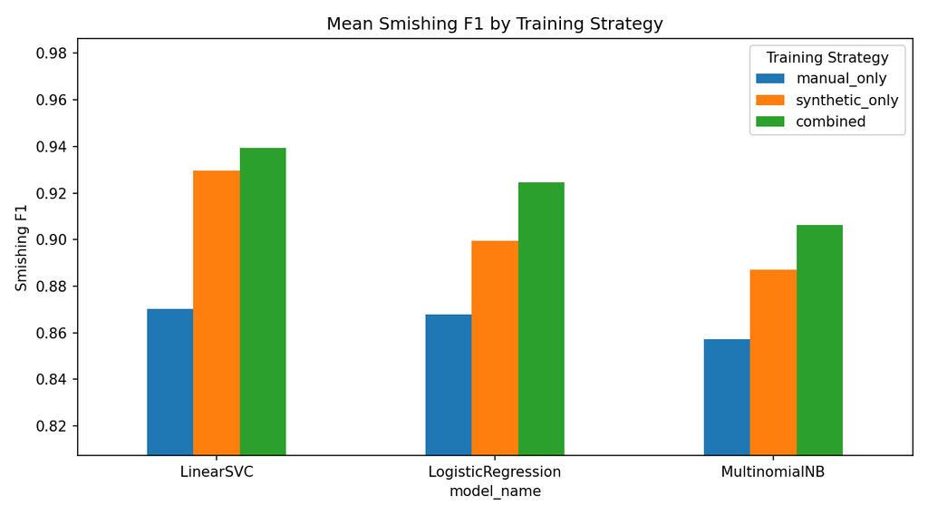

```python
from IPython.display import Image

display(Markdown("### Smishing F1 by Training Strategy"))
display(Image(filename=str(project_root / "outputs/figures/mean_smishing_f1_by_training_strategy.png")))
```

Smishing F1 Boxplot

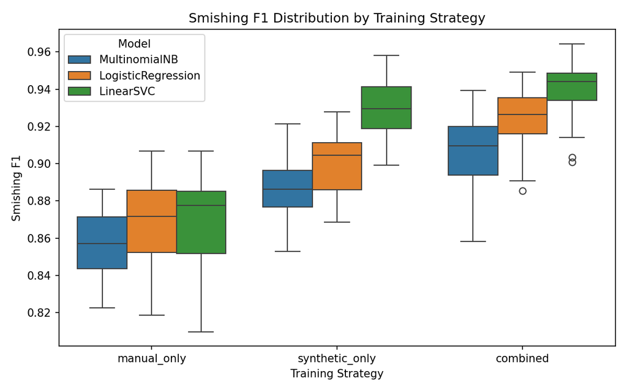

```python
display(Markdown("### Smishing F1 Boxplot"))
display(Image(filename=str(project_root / "outputs/figures/smishing_f1_boxplot_by_training_strategy.png")))
```

Best Model Confusion Matrix (Manual Holdout)

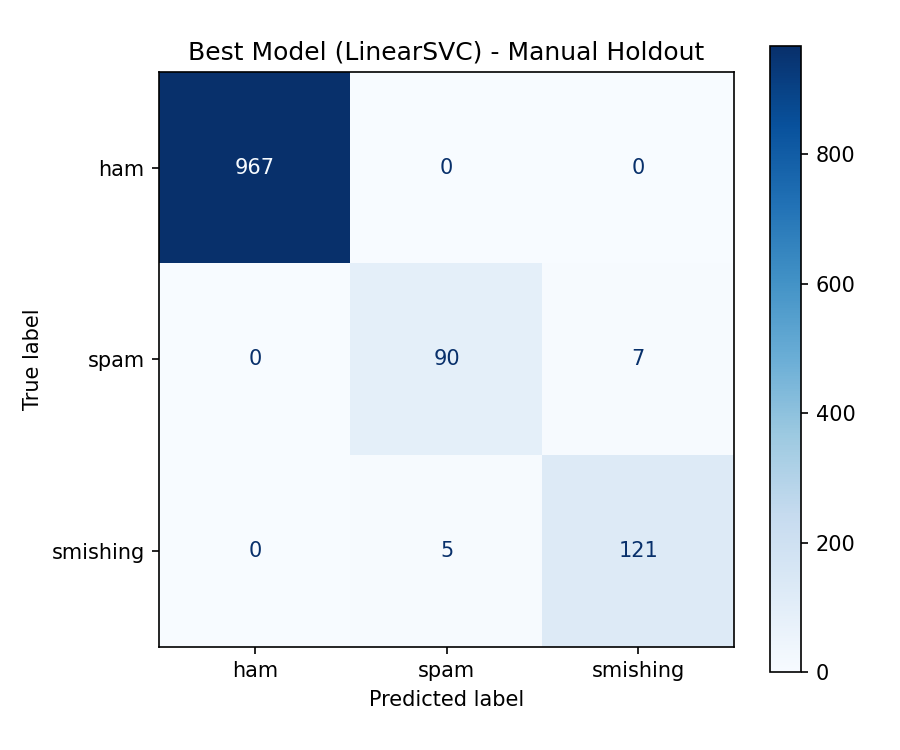

```python
display(Markdown("### Best Model Confusion Matrix (Manual Holdout)"))
display(Image(filename=str(project_root / "outputs/figures/confusion_matrix_best_model_manual_holdout.png")))
```

## 11. Statistical Summary

Detailed statistical hypothesis testing is performed in R (`r/statistical_analysis.R`). Here we preview the key comparisons.

```python
from scipy import stats

display(Markdown("### Quick Paired Comparisons (smishing F1, paired by seed+model)"))

comparisons = [
    ("manual_only", "synthetic_only"),
    ("manual_only", "combined"),
    ("synthetic_only", "combined"),
]

for exp_a, exp_b in comparisons:
    a = metrics_df[metrics_df["experiment_id"] == exp_a].sort_values(["seed", "model_name"])["smishing_f1"].values
    b = metrics_df[metrics_df["experiment_id"] == exp_b].sort_values(["seed", "model_name"])["smishing_f1"].values
    t_stat, p_val = stats.ttest_rel(a, b)
    diff = b.mean() - a.mean()
    print(f"{exp_a} vs {exp_b}: mean diff = {diff:+.4f}, t = {t_stat:.3f}, p = {p_val:.2e}")
```

Quick Paired Comparisons (smishing F1, paired by seed+model)

```
manual_only vs synthetic_only: mean diff = +0.0404, t = -15.622, p = 3.08e-27
manual_only vs combined: mean diff = +0.0583, t = -27.346, p = 4.37e-45
synthetic_only vs combined: mean diff = +0.0179, t = -11.800, p = 6.74e-20
```

## 12. Best Model Selection

```python
import json

with open(project_root / "outputs/models/best_model_metadata.json") as f:
    meta = json.load(f)

display(Markdown("### Best Model Metadata"))
for k, v in meta.items():
    print(f"  {k}: {v}")
```

Best Model Metadata

```
  model_name: LinearSVC
  training_experiment: combined
  primary_metric: smishing_f1
  mean_smishing_f1: 0.9393
  mean_macro_f1: 0.949
  labels: ['ham', 'spam', 'smishing']
  trained_at: 2026-06-01T20:29:26.706916+00:00
```

## 13. Artifact Export Summary

All outputs have been saved:

[output not shown]

```python
import os

for dirpath in ["data/processed", "outputs/metrics", "outputs/tables", "outputs/figures", "outputs/models"]:
    full = project_root / dirpath
    files = sorted(os.listdir(full)) if full.exists() else []
    print(f"\n{dirpath}/")
    for f in files:
        size = (full / f).stat().st_size
        print(f"  {f} ({size:,} bytes)")
```

```
data/processed/
  combined_clean.csv (3,119,191 bytes)
  manual_clean.csv (1,113,788 bytes)
  synthetic_clean.csv (2,005,468 bytes)

outputs/metrics/
  all_model_results.csv (81,519 bytes)
  classification_reports.jsonl (200,996 bytes)
  confusion_matrices.csv (106,359 bytes)

outputs/tables/
  cross_dataset_overlap.csv (394,247 bytes)
  dataset_audit.csv (215 bytes)
  effect_sizes.csv (1,199 bytes)
  experiment_performance_summary.csv (5,899 bytes)
  leakage_audit.csv (154 bytes)
  model_performance_summary.csv (5,872 bytes)
  statistical_tests.csv (2,480 bytes)
  top_duplicate_messages.csv (2,052 bytes)

outputs/figures/
  class_balance_comparison.png (23,446 bytes)
  confusion_matrix_best_model_manual_holdout.png (32,870 bytes)
  dataset_overlap_summary.png (31,225 bytes)
  duplicate_rate_comparison.png (20,114 bytes)
  mean_macro_f1_by_training_strategy.png (44,622 bytes)
  mean_smishing_f1_by_training_strategy.png (44,718 bytes)
  message_length_distribution.png (32,651 bytes)
  smishing_f1_boxplot_by_training_strategy.png (47,086 bytes)
  statistical_comparison_boxplots.png (43,068 bytes)

outputs/models/
  best_model.joblib (5,167,274 bytes)
  best_model_metadata.json (268 bytes)
```